# hw03

Arlo

# Assignment 3: dplyr/ggplot Part II

Load packages used in exercise

```r
library(tidyverse)
library(gapminder)
library(ggridges)
library(scales)
```

## Task Option 2: Min/max GDP/capita in each continent

### Gdp/capita range per continent - tibble

Group data continent then summarize the max and min values based on that grouping. => This tibble shows the minimum and maximum value of gdpPercap of each continent in gapminder.

```r
gapminder %>%
  group_by(continent) %>%
  summarize(max_GDPpercap = max(gdpPercap), min_GDPpercap = min(gdpPercap))
```

```
## # A tibble: 5 x 3
##   continent max_GDPpercap min_GDPpercap
##   <fct>             <dbl>         <dbl>
## 1 Africa           21951.          241.
## 2 Americas         42952.         1202.
## 3 Asia            113523.          331
## 4 Europe           49357.          974.
## 5 Oceania          34435.        10040.
```

### Gdp/capita range per continent - plot

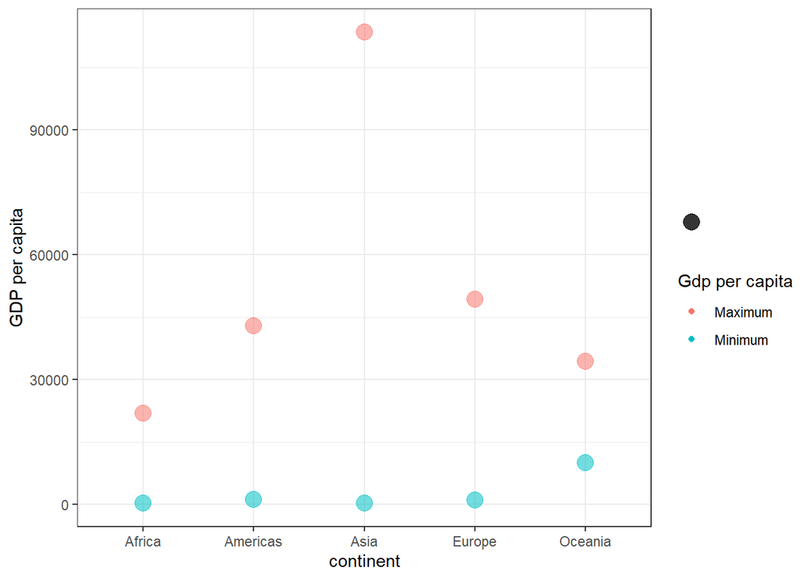

```r
gapminder %>%
  group_by(continent) %>%
  summarize(max_GDPpercap = max(gdpPercap), min_GDPpercap = min(gdpPercap)) %>%
      ggplot()+
      geom_point(aes(continent, max_GDPpercap, colour = "blue", alpha = 0.5, size = 2)) +
      geom_point(aes(continent, min_GDPpercap, colour = "red", alpha = 0.5, size = 2))+
        ylab("GDP per capita") +
        scale_alpha("", labels = "") +
        scale_size("", labels = "") +
        scale_colour_discrete("Gdp per capita", labels = c("Maximum", "Minimum")) +
        theme_bw()
```

## Task Option 5

### Life expectancy over time for all continents - tibble

Filter through tha gapminder data, and group together continents and years, allowing functions to be run individually to each group of continent, for each year. This allows the analysis of average life expectancy values for each continent over time, by grouping all countries’ data together that are within the same continent, then grouping each of those data by year as well.

```r
gapminder %>%
  select (continent, year, lifeExp) %>%
  group_by (continent, year) %>%
  arrange (continent, year) %>%
  summarize(ave_lifeEXp = mean(lifeExp))
```

```
## # A tibble: 60 x 3
## # Groups:   continent [5]
##    continent  year ave_lifeEXp
##    <fct>     <int>       <dbl>
##  1 Africa     1952        39.1
##  2 Africa     1957        41.3
##  3 Africa     1962        43.3
##  4 Africa     1967        45.3
##  5 Africa     1972        47.5
##  6 Africa     1977        49.6
##  7 Africa     1982        51.6
##  8 Africa     1987        53.3
##  9 Africa     1992        53.6
## 10 Africa     1997        53.6
## # ... with 50 more rows
```

### Life expectancy over time for all continents - plot

Plot each dataframe, isolating each continent so that average life expectancy values can be observed over time, then compared easily between continents. Allowing all data to be shown in the graph ensures the reader the confidence for using a line of best-fit, which clearly demonstrates the coarse scale changes of lifeExp over time for each continent.

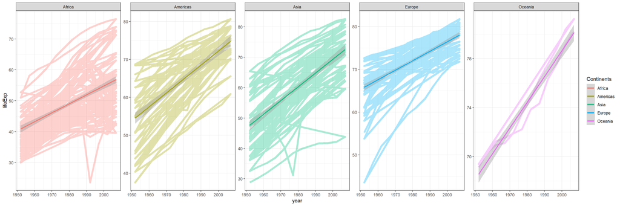

```r
gapminder %>%
  ggplot(aes(year, lifeExp, group = continent, colour = continent)) +
  geom_path(size = 2, alpha = 1/3) +
  facet_wrap(~ continent, nrow = 1, scales = "free") +
  scale_colour_discrete("Continents", labels = c(country_codes)) +
  geom_smooth(method = "lm") +
  theme_bw()
```

## Task option 6: Analyze Rwanda GDP relative to life expectancy

### Rwanda GDP vs life expectancy - tibble

Having seen the unique gdpPercap data in class demonstration, I chose to select only Rewanda’s data for furthur investigation. I chose to identify the increase in life expectancy for each year; and to use gross GDP instead of gdpPercap, in order to establish a relationship between GDP and life expectancy over time.

```r
(Rwanda <- gapminder%>%
  filter(country == "Rwanda") %>%
    mutate(lifeExp_inc= lifeExp - lag(lifeExp)) %>%
    mutate(GDP = gdpPercap*pop) %>%
    arrange(year))
```

```
## # A tibble: 12 x 8
##    country continent  year lifeExp     pop gdpPercap lifeExp_inc        GDP
##    <fct>   <fct>     <int>   <dbl>   <int>     <dbl>       <dbl>      <dbl>
##  1 Rwanda  Africa     1952    40   2534927      493.      NA         1.25e9
##  2 Rwanda  Africa     1957    41.5 2822082      540.       1.5       1.52e9
##  3 Rwanda  Africa     1962    43   3051242      597.       1.5       1.82e9
##  4 Rwanda  Africa     1967    44.1 3451079      511.       1.1       1.76e9
##  5 Rwanda  Africa     1972    44.6 3992121      591.       0.5       2.36e9
##  6 Rwanda  Africa     1977    45   4657072      670.       0.400     3.12e9
##  7 Rwanda  Africa     1982    46.2 5507565      882.       1.22      4.86e9
##  8 Rwanda  Africa     1987    44.0 6349365      848.      -2.20      5.38e9
##  9 Rwanda  Africa     1992    23.6 7290203      737.     -20.4       5.37e9
## 10 Rwanda  Africa     1997    36.1 7212583      590.      12.5       4.26e9
## 11 Rwanda  Africa     2002    43.4 7852401      786.       7.33      6.17e9
## 12 Rwanda  Africa     2007    46.2 8860588      863.       2.83      7.65e9
```

### Rwanda GDP vs life expectancy - plot

A graph showing the anomalies of GDP vs change in life expectancy for Rwanda over time. Including year labels allows reader to read the data over a time scale, despite the axes’ independance to time.

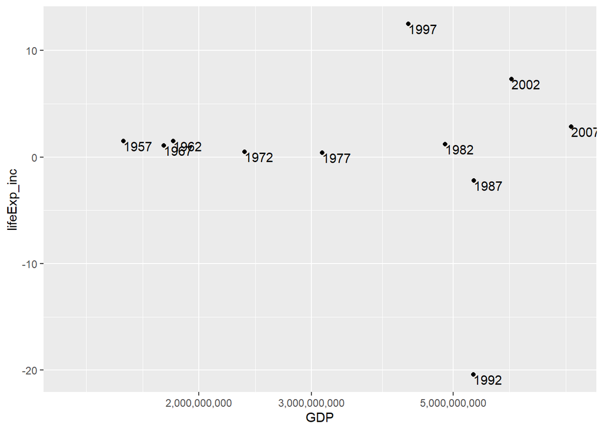

```r
Rwanda %>%
  ggplot(aes(GDP, lifeExp_inc)) +
      geom_point() +
  scale_x_log10(labels = scales::comma_format()) +
  geom_text(aes(label=year),hjust=0, vjust=1)
```